# QM_Code

2026-01-05

1. Data Wrangling

```r
# Load Required libraries
library(sf)              # modern spatial vector data (points/lines/polygons, CRS, spatial ops)
```

```r
library(tidyverse)       # core data wrangling + plotting (dplyr, readr, tibble, etc.)
library(tmap)            # thematic mapping for sf/raster (static + interactive maps)
library(tmaptools)       # helper tools for tmap (basemaps, geocoding, bbox utilities)
library(janitor)         # quick data cleaning (clean_names, tabulations, etc.)
library(stringr)         # string/text handling (str_detect, str_replace, regex work)
library(here)            # safe, project-root-based file paths (here("data", "file.csv"))
library(raster)          # older raster package (still used, but being replaced by terra)
library(terra)           # modern fast raster + vector grids (rast, crop, mask, project)
library(classInt)        # create class breaks for choropleths (jenks, quantiles, etc.)
library(ggplot2)         # general plotting (histograms, violins, geom_sf, etc.)
library(grid)            # low-level graphics; used for custom layout and insets
library(spatstat)        # point pattern analysis (ppp, Ripley’s K, quadrats, KDE)
library(fpc)             # clustering methods; here for DBSCAN on point coords
library(ggspatial)       # spatial helpers for ggplot (basemaps, north arrow, scalebar)
library(colorblindcheck) # check palettes for colour-blind accessibility
library(cols4all)        # big palette collection + GUI for choosing colour schemes
library(plotly)
library(rJava)
library(OpenStreetMap)
```

**Data Wrangling:** We are Going to prepare ready files to merge on the MSOA scale. then filter by intersect only For London

**1. Births File:** - Births File - Turn to CSV - Select Sheet Named 2 - Remove first 5 Rows - Filter Period only to the last 2 years for a larger sample 2019 - 2020 / 2020 - 2021. we selected these years as we wanted a larger sample - Group by area regardless of year. - do a sum column

```r
# 1) Read CSV file and skip first 5 rows
births_raw <- read_csv(here::here("data", "Births.csv"),
                       locale = locale(encoding = "latin1"),
                       na = " ", skip=5)
# 2) Periods we want to keep
keep_periods <- c(
  "2019-2020","2020-2021")

# 3) Clean column names (optional but highly recommended)
births <- births_raw %>%
  janitor::clean_names() %>%
  mutate(period = stringr::str_trim(period))  # in case there are sneaky spaces

# 4) Filter to the last periods, then group by area (MSOA), summing all age columns
births_msoa_sum <- births %>%
  filter(period %in% keep_periods) %>%

  group_by(msoa_2021_code) %>%
  summarise(
    across(
      c(`x19_and_under`, `x20_24`, `x25_29`, `x30_34`, `x35_39`, `x40_44`, `x45_and_over`),
      ~ sum(.x, na.rm = TRUE)
    ),
    .groups = "drop"
  ) %>%

  # 5) Add a total births column across age groups
  mutate(total_births = rowSums(across(c(`x19_and_under`, `x20_24`, `x25_29`, `x30_34`, `x35_39`, `x40_44`, `x45_and_over`)), na.rm = TRUE))

births_msoa_sum
```

```
## # A tibble: 7,264 × 9
##    msoa_2021_code x19_and_under x20_24 x25_29 x30_34 x35_39 x40_44 x45_and_over
##    <chr>                  <dbl>  <dbl>  <dbl>  <dbl>  <dbl>  <dbl>        <dbl>
##  1 E02000001                  0      1     11     42     43      9            5
##  2 E02000002                  5     30     67     78     40      8            3
##  3 E02000003                 11     55     91    113     61     18            2
##  4 E02000004                  1     19     49     58     23      6            2
##  5 E02000005                 11     51     80    122     79     17            3
##  6 E02000007                 12     47     89     91     55     16            0
##  7 E02000008                 19     44     98    103     76     20            5
##  8 E02000009                 12     49    102    117     80     20            1
##  9 E02000010                  8     30     81     97     44     11            1
## 10 E02000011                  4     39     53     67     33     13            1
## # ℹ 7,254 more rows
## # ℹ 1 more variable: total_births <dbl>
```

```r
# So now we have a table that has the last 2 years of births since 2019-2021 summed by MSOA
# later we have to aggregate for London boundry only.
```

**2. Population by Age File:** - Read file - Skip the first 3 Rows - Clean janitor - Keep Columns MSOA 2021 Code / MSOA 2021 Name / Keep columns contaning F for female then keep ages of 15 till 55 - and group by `x19_and_under`, `x20_24`, `x25_29`, `x30_34`, `x35_39`, `x40_44`, `x45_and_over` - then have total column

```r
# 1) Read CSV and clean columns for easier read
pop_raw <- read_csv(here::here("data", "Demographics_Age.csv"),
                       locale = locale(encoding = "latin1"),
                       na = " ", skip=3) %>%
  janitor::clean_names()
# 2) Columns we wish to keep
# select and filter + detect with F
pop_f <- pop_raw %>%
  select(msoa_2021_code, msoa_2021_name, matches("^f\\d+$")  # keeps f0, f1, f2... etc
  )

# 3) Group by age ranges same as birth ranges
pop_female_grouped <- pop_f %>%
  mutate(
    f_pop_19_and_under = rowSums(select(., f15:f19), na.rm = TRUE),
    f_pop_20_24        = rowSums(select(., f20:f24), na.rm = TRUE),
    f_pop_25_29        = rowSums(select(., f25:f29), na.rm = TRUE),
    f_pop_30_34        = rowSums(select(., f30:f34), na.rm = TRUE),
    f_pop_35_39        = rowSums(select(., f35:f39), na.rm = TRUE),
    f_pop_40_44        = rowSums(select(., f40:f44), na.rm = TRUE),
    f_pop_45_and_over  = rowSums(select(., f45:f55), na.rm = TRUE)
  ) %>%

# 4) Keep only needed columns
  select(
    msoa_2021_code,
    msoa_2021_name,
    starts_with("f_pop_")
  ) %>%

# 5) Total female population (15–55)
  mutate(
    f_pop_total = rowSums(across(starts_with("f_pop_")), na.rm = TRUE)
  )

pop_female_grouped
```

```
## # A tibble: 7,264 × 10
##    msoa_2021_code msoa_2021_name f_pop_19_and_under f_pop_20_24 f_pop_25_29
##    <chr>          <chr>                       <dbl>       <dbl>       <dbl>
##  1 E02002483      Hartlepool 001                339         237         366
##  2 E02002484      Hartlepool 002                379         306         380
##  3 E02002485      Hartlepool 003                279         207         250
##  4 E02002489      Hartlepool 007                271         345         223
##  5 E02002490      Hartlepool 008                167         138         199
##  6 E02002491      Hartlepool 009                218         175         211
##  7 E02002492      Hartlepool 010                188         173         206
##  8 E02002493      Hartlepool 011                163         123         189
##  9 E02002494      Hartlepool 012                271         255         265
## 10 E02006909      Hartlepool 014                356         249         348
## # ℹ 7,254 more rows
## # ℹ 5 more variables: f_pop_30_34 <dbl>, f_pop_35_39 <dbl>, f_pop_40_44 <dbl>,
## #   f_pop_45_and_over <dbl>, f_pop_total <dbl>
```

```r
# 1) Read CSV file and filter only for MSOA
house_raw <- read_csv(here::here("data", "Housing.csv"),
                       locale = locale(encoding = "latin1"),
                       na = " ", skip=9) %>%
  janitor::clean_names() %>%
  filter(geography3 == "MSOA")
# 2) change everything to numeric
house_raw %>%
  summarise(across(starts_with("x"), ~ class(.x)[1])) %>%
  pivot_longer(everything(), names_to = "col", values_to = "class") %>%
  filter(class != "numeric")
```

```
## # A tibble: 37 × 2
##    col   class
##    <chr> <chr>
##  1 x1_4  character
##  2 x2_5  character
##  3 x3_6  character
##  4 x4_7  character
##  5 x1_10 character
##  6 x2_11 character
##  7 x3_12 character
##  8 x4_13 character
##  9 x1_16 character
## 10 x2_17 character
## # ℹ 27 more rows
```

```r
house_clean <- house_raw %>%
  mutate(across(where(is.character), ~ na_if(.x, "-"))) %>%
  mutate(across(starts_with("x"),
                ~ if (is.character(.x)) parse_number(.x) else .x))

# 3) Group Rooms and rename for easier read

house <- house_clean %>%
  mutate(
    `1bed` = rowSums(across(c(x1_4, x1_10, x1_16, x1_22, x1_28)), na.rm = TRUE),
    `2bed` = rowSums(across(c(x2_5, x2_11, x2_17, x2_23, x2_29)), na.rm = TRUE),
    `3bed` = rowSums(across(c(x3_6, x3_12, x3_18, x3_24, x3_30)), na.rm = TRUE),
    `4bed` = rowSums(across(c(x4_7, x4_13, x4_19, x4_25, x4_31)), na.rm = TRUE)
  ) %>%
# 4) Select columns we need only
  select(area_code4, `1bed`:`4bed`) %>%
  mutate(
    total_above2 = rowSums(across(c(`2bed`, `3bed`, `4bed`)), na.rm = TRUE),
    total        = rowSums(across(c(`1bed`, `2bed`, `3bed`, `4bed`)), na.rm = TRUE)
  )

# 5) create calc of total houses over 2 bedroom and one bedroom with percenatege
house <- house %>%
    mutate(
    total_above2 = rowSums(across(c(`2bed`, `3bed`, `4bed`)), na.rm = TRUE),
    total        = rowSums(across(c(`1bed`, `2bed`, `3bed`, `4bed`)), na.rm = TRUE),
    pct_above2 = (total_above2/total),
    pct_below2 = (`1bed`/total)
    )
```

**4. Income File:** - Read file CSV - no need to remove rows - clean names - create column calac housing prices per MSOA

```r
# 1) Read CSV file and filter only for MSOA
income_raw <- read_csv(here::here("data", "Income.csv"),
                       locale = locale(encoding = "latin1"),
                       na = " ", skip=0) %>%
  janitor::clean_names() %>%
  rename(income_msoa = areacd,
         net_before = disposable_net_annual_income_before_housing_costs_thousands,
         net_after = disposable_net_annual_income_after_housing_costs_thousands)
#2) Calc housing prices per MSOA avg
income <- income_raw %>%
  mutate(house_price = net_before - net_after)
```

**Step Two: Master DATA FRAME with all variables (SHOCKING)**

```r
# Lets create one master data frame
master_df <- pop_female_grouped %>%
  left_join(births_msoa_sum, by = "msoa_2021_code") %>%
  left_join(income, by = c("msoa_2021_code" = "income_msoa")) %>%
  left_join(house, by = c("msoa_2021_code" = "area_code4"))
```

```r
# lets rename columns
master_df <- master_df %>%
  rename(b_19_and_under = x19_and_under,
         b_20_24 = x20_24,
         b_25_29 = x25_29,
         b_30_34 = x30_34,
         b_35_39 = x35_39,
         b_40_44 = x40_44,
         b_45_and_over = x45_and_over,
         b_total = total_births,
         income_net_before = net_before,
         income_net_after = net_after,
         income_net_house = house_price,
         h_1bed = `1bed`,
         h_2bed = `2bed`,
         h_3bed = `3bed`,
         h_4bed = `4bed`,
         h_total_above2 = total_above2,
         h_total = total,
         h_pct_above2 = pct_above2,
         h_pct_below2 = pct_below2
  )
```

```r
names(master_df)
```

```
##  [1] "msoa_2021_code"     "msoa_2021_name"     "f_pop_19_and_under"
##  [4] "f_pop_20_24"        "f_pop_25_29"        "f_pop_30_34"
##  [7] "f_pop_35_39"        "f_pop_40_44"        "f_pop_45_and_over"
## [10] "f_pop_total"        "b_19_and_under"     "b_20_24"
## [13] "b_25_29"            "b_30_34"            "b_35_39"
## [16] "b_40_44"            "b_45_and_over"      "b_total"
## [19] "income_net_before"  "income_net_after"   "income_net_house"
## [22] "h_1bed"             "h_2bed"             "h_3bed"
## [25] "h_4bed"             "h_total_above2"     "h_total"
## [28] "h_pct_above2"       "h_pct_below2"
```

2.1 Create New Column for fertility

```r
# Create a column that calculates the total number of fertility per 1000 women
master_df <- master_df %>%
  mutate(fertility_rate = (b_total / f_pop_total) * 1000)
```

2.2 Reading SHP files

```r
london <- st_read(here::here("shp",
                            "gla",
                            "gla",
                            "London_GLA_Boundary.shp"))
borough <- st_read(here::here("shp",
                            "statistical-gis-boundaries-london",
                            "statistical-gis-boundaries-london",
                            "ESRI",
                            "London_Borough_Excluding_MHW.shp"))
# vector of borough MSOA shapefile paths
files <- list.files(
  "shp/LB_MSOA2021_shp/msoa2021/",
  pattern = "\\.shp$",
  full.names = TRUE
)

# read + combine
msoa <- files %>%
  lapply(st_read, quiet = TRUE) %>%
  bind_rows() %>%
  clean_names()
```

```r
# Reorganize msoa file
msoa_clean <- msoa %>%
  clean_names() %>%
  select(msoa21cd,
         lad22nm,
         geometry)
```

2.3 Trim master data frame to just London

```r
master_df_london <- master_df %>%
  semi_join(
    msoa_clean,
    by = c("msoa_2021_code" = "msoa21cd")
  ) %>%
  drop_na()
```

**Step Three: First Observations**

```r
library(psych)
psych::describe(master_df_london %>% select(fertility_rate, h_pct_below2, income_net_house))
```

```
##                  vars   n  mean    sd median trimmed   mad   min    max  range
## fertility_rate      1 963 80.48 19.05  80.23   79.84 15.32 20.27 256.30 236.04
## h_pct_below2        2 963  0.21  0.12   0.21    0.21  0.14  0.01   0.58   0.57
## income_net_house    3 963  5.69  4.63   5.90    5.74  4.31 -9.43  24.76  34.20
##                  skew kurtosis   se
## fertility_rate   2.22    17.32 0.61
## h_pct_below2     0.37    -0.56 0.00
## income_net_house 0.02     0.54 0.15
```

**Step Four: Transform master London into a simple feature object**

```r
# Create the spatial version of your master data
master_london_sf <- msoa_clean %>%
  inner_join(master_df_london, by = c("msoa21cd" = "msoa_2021_code")) %>%
  st_transform(27700) # Re-confirming OSGB36 CRS
```

Map: MSOA Fertility Above and Below London Avg.

```r
library(tmap)

# Calculate the mean to use as a midpoint
mean_fert <- mean(master_london_sf$fertility_rate, na.rm = TRUE)

tm_shape(master_london_sf) +
  tm_polygons("fertility_rate",
              palette = "-RdBu", # Red-Blue diverging palette
              midpoint = mean_fert,
              style = "pretty",
              title = "Fertility vs. London Avg") +
  tm_layout(main.title = "MSOA Fertility: Above/Below London Average",
            legend.outside = TRUE)
```

```
## ── tmap v3 code detected ───────────────────────────────────────────────────────
```

[output not shown]

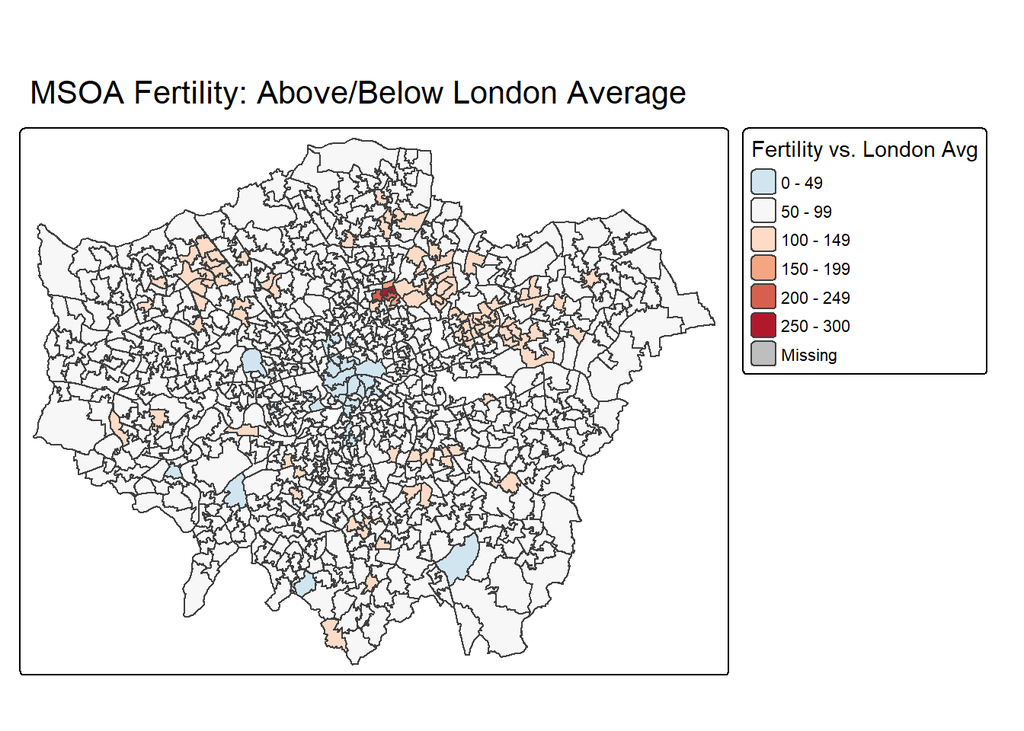

Graph: Histogram Fertility Before Log

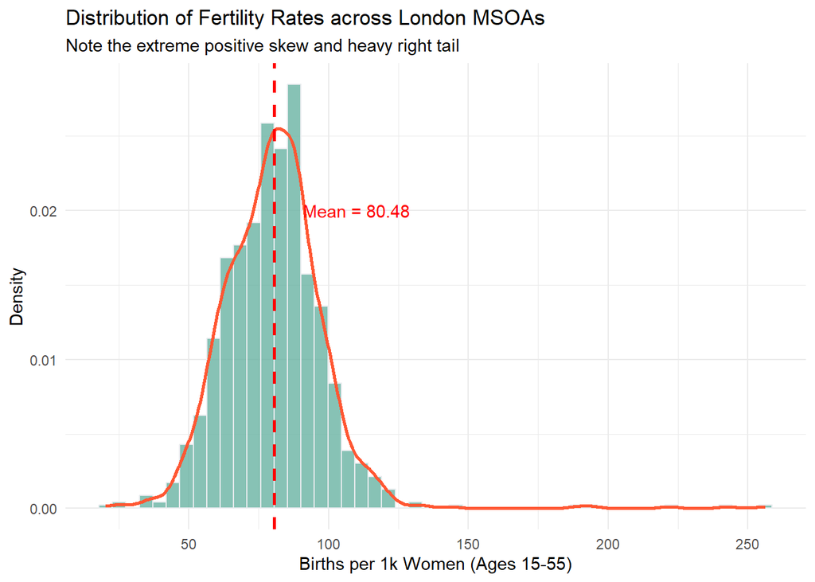

```r
library(ggplot2)

ggplot(master_df_london, aes(x = fertility_rate)) +
  geom_histogram(aes(y = ..density..),
                 bins = 50,
                 fill = "#69b3a2",
                 color = "#e9ecef",
                 alpha = 0.8) +
  geom_density(color = "#ff5733", size = 1) +
  geom_vline(aes(xintercept = mean(fertility_rate)),
             color = "red", linetype = "dashed", size = 1) +
  annotate("text", x = 110, y = 0.02,
           label = paste("Mean =", round(mean(master_df_london$fertility_rate), 2)),
           color = "red") +
  labs(title = "Distribution of Fertility Rates across London MSOAs",
       subtitle = "Note the extreme positive skew and heavy right tail",
       x = "Births per 1k Women (Ages 15-55)",
       y = "Density") +
  theme_minimal()
```

Scatter: Scatter Plot Before Log

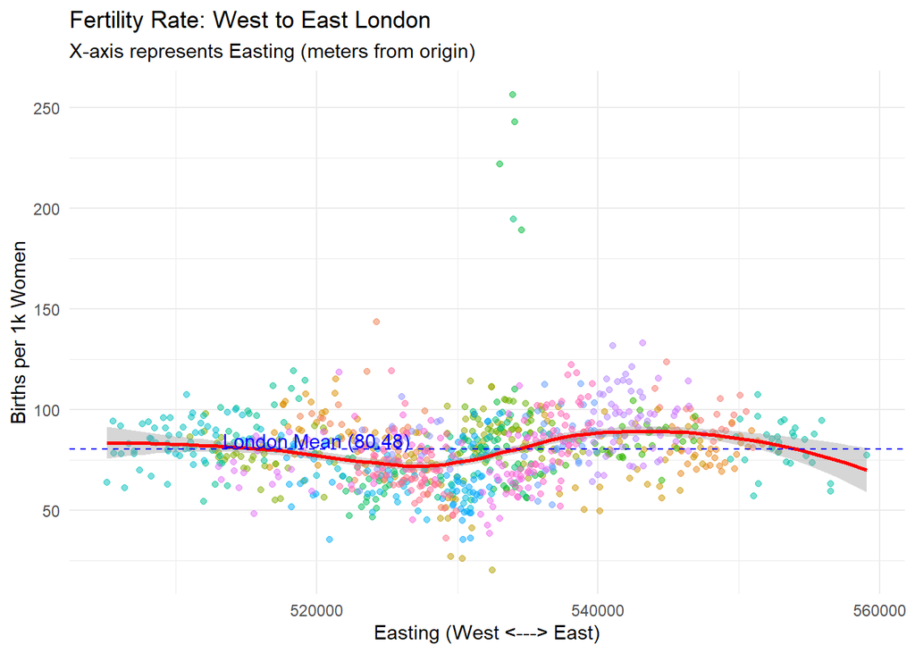

```r
library(ggplot2)
library(sf)

# Extract Easting (X) and Northing (Y) from your sf object
master_coords <- master_london_sf %>%
  st_centroid() %>%
  st_coordinates() %>%
  as.data.frame()
# Combine back with your data
master_plot_data <- cbind(master_london_sf, master_coords)

ggplot(master_plot_data, aes(x = X, y = fertility_rate)) +
  geom_point(aes(color = lad22nm), alpha = 0.5) +
  geom_smooth(method = "loess", color = "red", size = 1) +
  geom_hline(yintercept = 80.48, linetype = "dashed", color = "blue") +
  annotate("text", x = 520000, y = 85, label = "London Mean (80.48)", color = "blue") +
  theme_minimal() +
  theme(legend.position = "none") + # Hidden for clarity
  labs(title = "Fertility Rate: West to East London",
       subtitle = "X-axis represents Easting (meters from origin)",
       x = "Easting (West <---> East)",
       y = "Births per 1k Women")
```

Top High Fertility

```r
# Pulling the top 5 MSOAs to identify their Boroughs (LAD11NM)

top_outliers <- master_london_sf %>%
  arrange(desc(fertility_rate)) %>%
  head(5) %>%
  select(msoa21cd,
         lad22nm,
         fertility_rate)

print(top_outliers)
```

```
## Simple feature collection with 5 features and 3 fields
## Geometry type: POLYGON
## Dimension:     XY
## Bounding box:  xmin: 532527.2 ymin: 186596.6 xmax: 534992 ymax: 189055.4
## Projected CRS: OSGB36 / British National Grid
##    msoa21cd  lad22nm fertility_rate                       geometry
## 1 E02000345  Hackney       256.3044 POLYGON ((534501.3 188166.5...
## 2 E02000348  Hackney       242.9427 POLYGON ((534225.8 187952, ...
## 3 E02000347  Hackney       221.8693 POLYGON ((533314.2 188008.1...
## 4 E02000425 Haringey       194.5749 POLYGON ((534284 188269, 53...
## 5 E02006921  Hackney       189.2231 POLYGON ((534845.9 187532.4...
```

Bad Map

```r
library(ggspatial)
library(viridis)
```

```
## Zoom: 11
```

```
## Fetching 35 missing tiles
```

[output not shown]

```
## ...complete!
```

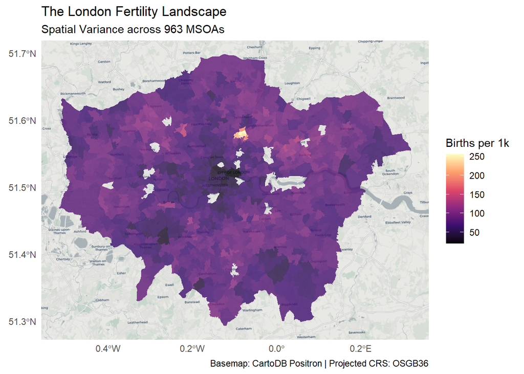

```r
ggplot(master_london_sf) +
  # Adds the clean, static gray-scale basemap
  annotation_map_tile(type = "cartolight", zoom = 11, forcedownload = TRUE) +
  # Colors the MSOAs by your skewed fertility rate
  geom_sf(aes(fill = fertility_rate), color = NA, alpha = 0.8) +
  # Uses the professional Magma palette you liked
  scale_fill_viridis_c(option = "magma", name = "Births per 1k") +
  theme_minimal() +
  labs(title = "The London Fertility Landscape",
       subtitle = "Spatial Variance across 963 MSOAs",
       caption = "Basemap: CartoDB Positron | Projected CRS: OSGB36") +
  theme(legend.position = "right")
```

**Step Five: Analysis and Logs** - Log Transformation to all three variables - Histograms of before and after - Notes: “To address negative values in the housing cost estimate (min = -9.43) and allow for $log_{10}$ transformation, a constant offset of +10 was applied to all observations in the income_net_house variable”.

```r
# Define a tiny epsilon to prevent math errors at exactly 0 or 1
eps <- 0.001

master_london_sf <- master_london_sf %>%
  mutate(
    # 1. Log for Fertility (standard for counts with outliers)
    log_fertility = log10(fertility_rate),

    # 2. Log + 10 for Housing Cost (standard for income-based data)
    log_housing_cost = log10(income_net_house + 10),

    # 3. Logit for Small Dwellings (Best for proportions/percentages)
    logit_small_dwellings = log((h_pct_below2 + eps) / (1 - h_pct_below2 + eps))
  )
```

Fertility rates were log₁₀-transformed to reduce right skew. Housing income was log-transformed after adding a constant to accommodate negative values. The proportion of small dwellings was logit-transformed to respect its bounded nature and improve distributional symmetry.

Histogram Fertility_rate + log_fertility

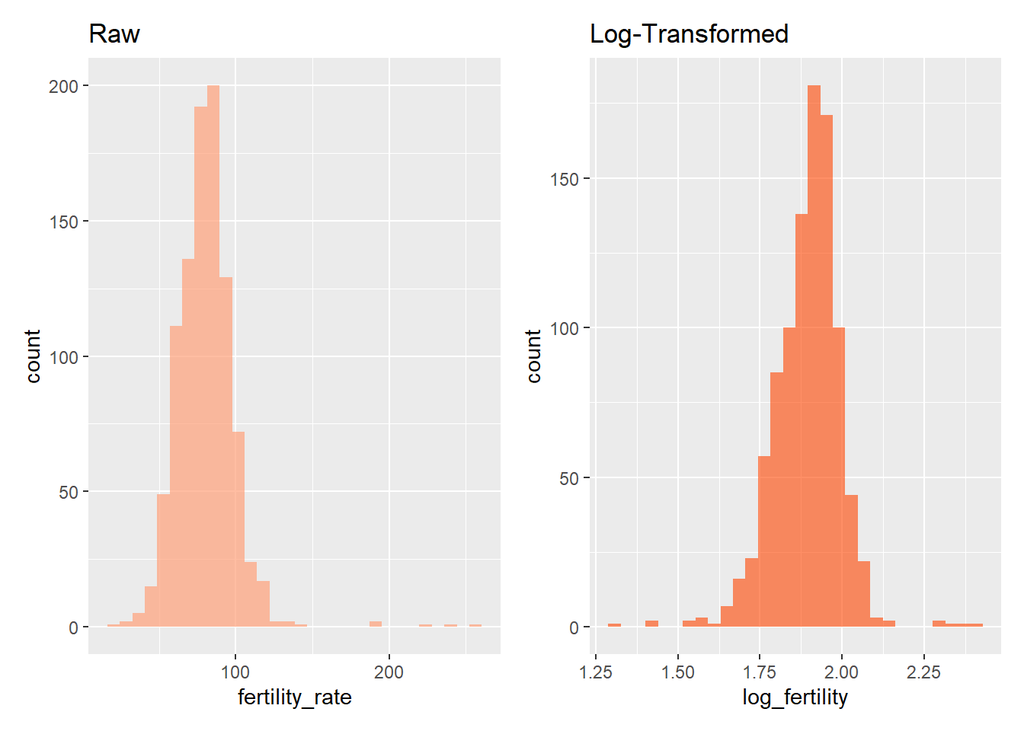

```r
# 2. Generate the Before/After Histograms
library(patchwork)
p1 <- ggplot(master_london_sf, aes(x=fertility_rate)) + geom_histogram(fill="lightsalmon", alpha=0.7) + labs(title="Raw")
p2 <- ggplot(master_london_sf, aes(x=log_fertility)) + geom_histogram(fill="orangered", alpha=0.6) + labs(title="Log-Transformed")
p1 + p2
```

Histogram income_net_house + log_housing_cost

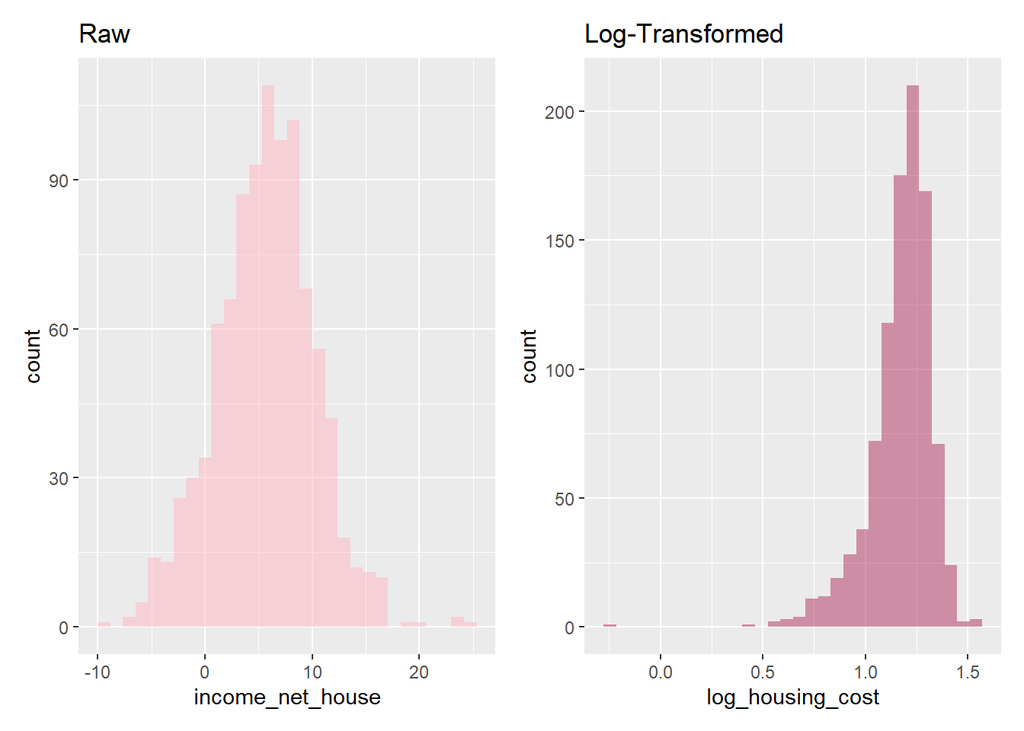

```r
# 3. Generate the Before/After Histograms
i1 <- ggplot(master_london_sf, aes(x=income_net_house)) + geom_histogram(fill="lightpink", alpha=0.5) + labs(title="Raw")
i2 <- ggplot(master_london_sf, aes(x=log_housing_cost)) + geom_histogram(fill="maroon", alpha=0.5) + labs(title="Log-Transformed")
i1 + i2
```

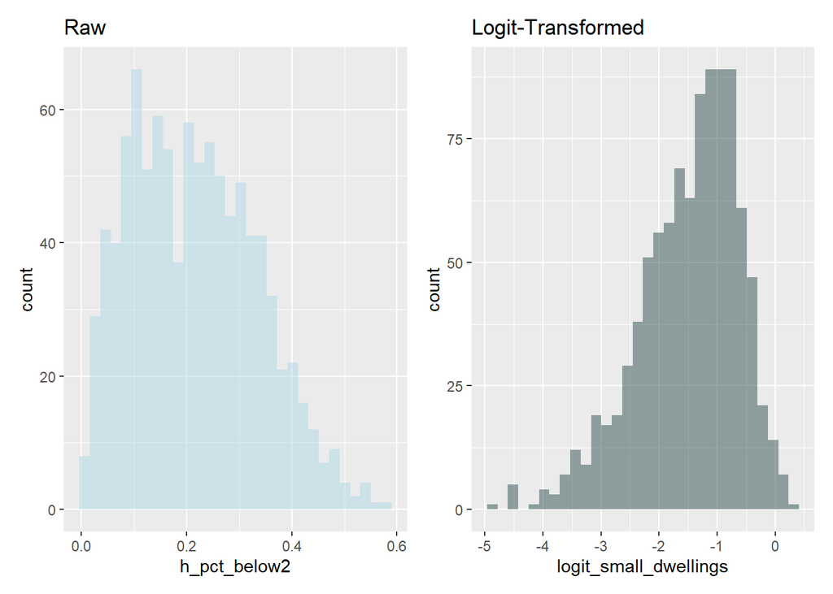

```r
# 3. Generate the Before/After Histograms
h1 <- ggplot(master_london_sf, aes(x=h_pct_below2)) + geom_histogram(fill="lightblue", alpha=0.5) + labs(title="Raw")
h2 <- ggplot(master_london_sf, aes(x=logit_small_dwellings)) + geom_histogram(fill="darkslategray", alpha=0.5) + labs(title="Logit-Transformed")
h1 + h2
```

Pearson Correlation

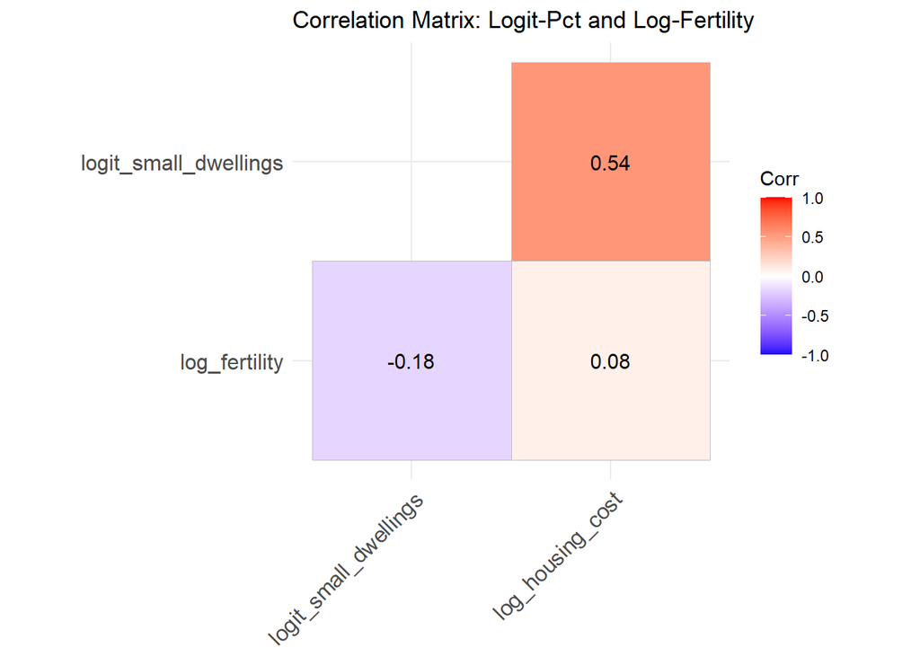

```r
library(ggcorrplot)
# This selects your three 'perfected' variables
final_analysis_vars <- master_london_sf %>%
  st_drop_geometry() %>%
  select(log_fertility, logit_small_dwellings, log_housing_cost)

# Calculate the correlations
final_matrix <- cor(final_analysis_vars, use = "complete.obs")

# Print the final visual
ggcorrplot(final_matrix,
           type = "lower",
           lab = TRUE,
           title = "Correlation Matrix: Logit-Pct and Log-Fertility")
```

Housing cost and the prevalence of small dwellings are strongly correlated, reflecting underlying spatial and market structures in London. Fertility shows only a weak negative association with dwelling size and virtually no direct association with housing cost, suggesting that housing form rather than price alone may play a more important role in shaping fertility pattern

```r
lm(log_fertility ~ logit_small_dwellings + log_housing_cost, data = master_london_sf)
```

```
##
## Call:
## lm(formula = log_fertility ~ logit_small_dwellings + log_housing_cost,
##     data = master_london_sf)
##
## Coefficients:
##           (Intercept)  logit_small_dwellings       log_housing_cost
##               1.65253               -0.03638                0.16034
```

Anova test

```r
# One-Way ANOVA: Does Fertility differ by Borough?
# Replace 'borough_name' with the actual column name in your data
anova_res <- aov(log_fertility ~ lad22nm, data = master_london_sf)
summary(anova_res)
```

```
##              Df Sum Sq Mean Sq F value Pr(>F)
## lad22nm      32  3.484  0.1089   17.02 <2e-16 ***
## Residuals   930  5.948  0.0064
## ---
## Signif. codes:  0 '***' 0.001 '**' 0.01 '*' 0.05 '.' 0.1 ' ' 1
```

The p-value (Pr(>F)): It is < 2e-16. This is statistically as small as it gets, meaning the probability that the differences between London boroughs are just “random chance” is effectively zero.

The F-value: At 17.02, it shows that the variation in fertility between boroughs is much larger than the variation within each borough. Conclusion for your notes: You have proven that Borough matters. This justifies moving away from a simple linear regression (which treats all 963 MSOAs as independent) to a Linear Mixed Effects (LME) model (which recognizes that MSOAs are nested within boroughs).

A one-way ANOVA indicates significant differences in mean log-fertility across London boroughs (F = 17.02, p < 0.001), suggesting that fertility patterns are structured by borough-level context rather than being randomly distributed across space.

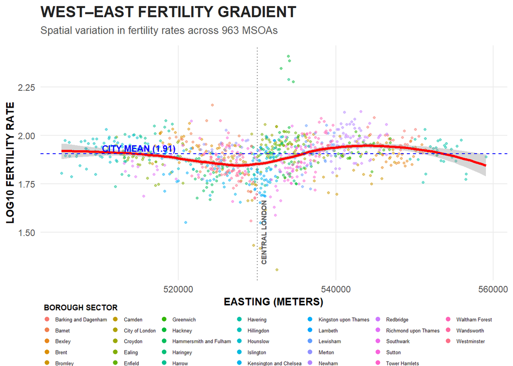

```r
library(ggplot2)
library(sf)

# 1. Coordinate Reset and Variable Setup
master_london_sf <- st_transform(master_london_sf, crs = 27700)
coords <- st_coordinates(st_centroid(master_london_sf))
master_london_sf$X <- coords[, 1]   # <-- EASTING
master_london_sf$Y <- coords[, 2]   # (still available if needed)

log_mean_val <- log10(80.48)

# 2. WEST–EAST Plot
ggplot(master_london_sf, aes(x = X, y = log_fertility)) +
  geom_point(aes(color = lad22nm), alpha = 0.5, size = 0.9) +
  geom_smooth(method = "loess", color = "red", linewidth = 1.1, se = TRUE) +
  geom_hline(yintercept = log_mean_val, linetype = "dashed", color = "blue") +

  # Example central easting line (adjust if needed)
  geom_vline(xintercept = 530000, linetype = "dotted", color = "grey40") +

  # WEST–EAST annotation (mirroring your style)
  annotate("text", x = 530000 + 800, y = 1.5, label = "CENTRAL LONDON",
           angle = 90, size = 2.4, color = "grey35",
           fontface = "bold", family = "sans") +

  annotate("text", x = 515000, y = log_mean_val + 0.03,
           label = "CITY MEAN (1.91)", color = "blue",
           size = 3, fontface = "bold", family = "sans") +

  theme_minimal(base_family = "sans") +
  theme(
    plot.title = element_text(face = "bold", size = 15, color = "#222222"),
    plot.subtitle = element_text(size = 10, color = "#555555", margin = margin(b = 10)),
    axis.title = element_text(face = "bold", size = 10),
    panel.grid.minor = element_blank(),
    legend.position = "bottom",
    legend.title = element_text(size = 7.5, face = "bold"),
    legend.text = element_text(size = 5),
    legend.key.height = unit(0.04, "cm"),
    legend.key.width = unit(0.2, "cm"),
    legend.spacing.x = unit(0.08, "cm"),
    legend.box.spacing = unit(0.05, "cm"),
    legend.margin = margin(t = -5, b = -5)
  ) +

  guides(color = guide_legend(
    ncol = 8,
    title.position = "top",
    override.aes = list(alpha = 1, size = 1.8)
  )) +

  labs(
    title = "WEST–EAST FERTILITY GRADIENT",
    subtitle = "Spatial variation in fertility rates across 963 MSOAs",
    x = "EASTING (METERS)",
    y = "LOG10 FERTILITY RATE",
    color = "BOROUGH SECTOR"
  )
```

The plot reveals a clear east–west spatial gradient in fertility across London, with lower values concentrated in central–western MSOAs and higher values toward the east. The non-linear trend and borough-level clustering suggest that fertility patterns are spatially structured and reflect broader socio-spatial processes rather than random variation.

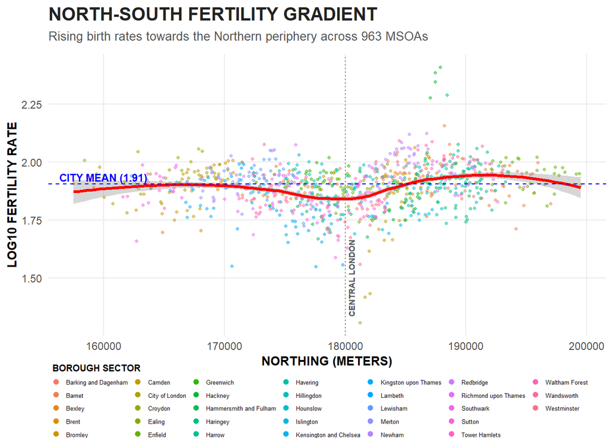

```r
library(ggplot2)
library(sf)

# 1. Coordinate Reset and Variable Setup
master_london_sf <- st_transform(master_london_sf, crs = 27700)
coords <- st_coordinates(st_centroid(master_london_sf))
master_london_sf$Y <- coords[, 2]

log_mean_val <- log10(80.48)

# 2. Refined Plotting Code
ggplot(master_london_sf, aes(x = Y, y = log_fertility)) +
  geom_point(aes(color = lad22nm), alpha = 0.5, size = 0.9) +
  geom_smooth(method = "loess", color = "red", linewidth = 1.1, se = TRUE) +
  geom_hline(yintercept = log_mean_val, linetype = "dashed", color = "blue") +
  geom_vline(xintercept = 180000, linetype = "dotted", color = "grey40") +

  # Improved annotation placement
  annotate("text", x = 180000 + 500, y = 1.5, label = "CENTRAL LONDON",
         angle = 90, size = 2.4, color = "grey35", fontface = "bold", family = "sans")+
  annotate("text", x = 160000, y = log_mean_val + 0.03,
           label = "CITY MEAN (1.91)", color = "blue", size = 3, fontface = "bold", family = "sans") +

  theme_minimal(base_family = "sans") +
  theme(
    plot.title = element_text(face = "bold", size = 15, color = "#222222"),
    plot.subtitle = element_text(size = 10, color = "#555555", margin = margin(b = 10)),
    axis.title = element_text(face = "bold", size = 10),
    panel.grid.minor = element_blank(),
    legend.position = "bottom",
    legend.title = element_text(size = 7.5, face = "bold"),
    legend.text = element_text(size = 5),
    legend.key.height = unit(0.04, "cm"),
    legend.key.width = unit(0.2, "cm"),
    legend.spacing.x = unit(0.08, "cm"),
    legend.box.spacing = unit(0.05, "cm"),
    legend.margin = margin(t = -5, b = -5)
  ) +

  guides(color = guide_legend(ncol = 8, title.position = "top",
                              override.aes = list(alpha = 1, size = 1.8))) +

  labs(
    title = "NORTH-SOUTH FERTILITY GRADIENT",
    subtitle = "Rising birth rates towards the Northern periphery across 963 MSOAs",
    x = "NORTHING (METERS)",
    y = "LOG10 FERTILITY RATE",
    color = "BOROUGH SECTOR"
  )
```

Linear regression

```r
lm_simple <- lm(
  log_fertility ~ logit_small_dwellings + log_housing_cost,
  data = master_london_sf
)

summary(lm_simple)
```

```
##
## Call:
## lm(formula = log_fertility ~ logit_small_dwellings + log_housing_cost,
##     data = master_london_sf)
##
## Residuals:
##      Min       1Q   Median       3Q      Max
## -0.56327 -0.05507  0.00755  0.05785  0.51222
##
## Coefficients:
##                        Estimate Std. Error t value Pr(>|t|)
## (Intercept)            1.652526   0.031919  51.772  < 2e-16 ***
## logit_small_dwellings -0.036378   0.004247  -8.565  < 2e-16 ***
## log_housing_cost       0.160339   0.023792   6.739 2.74e-11 ***
## ---
## Signif. codes:  0 '***' 0.001 '**' 0.01 '*' 0.05 '.' 0.1 ' ' 1
##
## Residual standard error: 0.09526 on 960 degrees of freedom
## Multiple R-squared:  0.07646,    Adjusted R-squared:  0.07453
## F-statistic: 39.74 on 2 and 960 DF,  p-value: < 2.2e-16
```

```r
lm_std <- lm(
  log_fertility ~ scale(logit_small_dwellings) + scale(log_housing_cost),
  data = master_london_sf
)

summary(lm_std)
```

```
##
## Call:
## lm(formula = log_fertility ~ scale(logit_small_dwellings) + scale(log_housing_cost),
##     data = master_london_sf)
##
## Residuals:
##      Min       1Q   Median       3Q      Max
## -0.56327 -0.05507  0.00755  0.05785  0.51222
##
## Coefficients:
##                               Estimate Std. Error t value Pr(>|t|)
## (Intercept)                   1.894502   0.003070 617.152  < 2e-16 ***
## scale(logit_small_dwellings) -0.031371   0.003663  -8.565  < 2e-16 ***
## scale(log_housing_cost)       0.024683   0.003663   6.739 2.74e-11 ***
## ---
## Signif. codes:  0 '***' 0.001 '**' 0.01 '*' 0.05 '.' 0.1 ' ' 1
##
## Residual standard error: 0.09526 on 960 degrees of freedom
## Multiple R-squared:  0.07646,    Adjusted R-squared:  0.07453
## F-statistic: 39.74 on 2 and 960 DF,  p-value: < 2.2e-16
```

Print

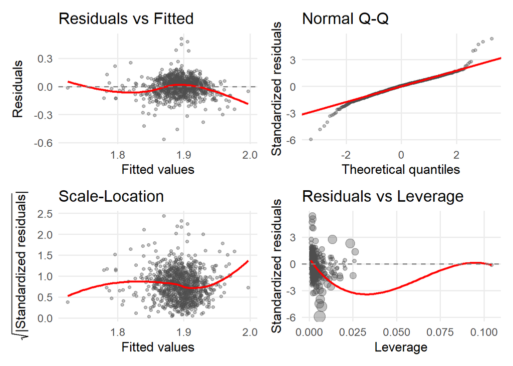

```r
library(broom)
library(dplyr)
library(ggplot2)

m <- lm(log_fertility ~ logit_small_dwellings + log_housing_cost, data = master_london_sf)

aug <- augment(m)  # adds .fitted, .resid, .std.resid, .hat, .cooksd

# 1) Residuals vs Fitted
p1 <- ggplot(aug, aes(.fitted, .resid)) +
  geom_point(alpha = 0.35, size = 1.2, color = "grey30") +
  geom_smooth(method = "loess", se = FALSE, linewidth = 1, color = "red") +
  geom_hline(yintercept = 0, linetype = "dashed", linewidth = 0.6, color = "grey50") +
  labs(title = "Residuals vs Fitted", x = "Fitted values", y = "Residuals") +
  theme_minimal(base_size = 13) +
  theme(panel.grid.minor = element_blank())

# 2) Q-Q Plot of standardized residuals
p2 <- ggplot(aug, aes(sample = .std.resid)) +
  stat_qq(alpha = 0.35, size = 1.2, color = "grey30") +
  stat_qq_line(linewidth = 1, color = "red") +
  labs(title = "Normal Q-Q", x = "Theoretical quantiles", y = "Standardized residuals") +
  theme_minimal(base_size = 13) +
  theme(panel.grid.minor = element_blank())

# 3) Scale-Location
p3 <- ggplot(aug, aes(.fitted, sqrt(abs(.std.resid)))) +
  geom_point(alpha = 0.35, size = 1.2, color = "grey30") +
  geom_smooth(method = "loess", se = FALSE, linewidth = 1, color = "red") +
  labs(title = "Scale-Location", x = "Fitted values", y = expression(sqrt("|Standardized residuals|"))) +
  theme_minimal(base_size = 13) +
  theme(panel.grid.minor = element_blank())

# 4) Residuals vs Leverage (with Cook's distance highlight)
p4 <- ggplot(aug, aes(.hat, .std.resid)) +
  geom_point(aes(size = .cooksd), alpha = 0.35, color = "grey30") +
  geom_smooth(method = "loess", se = FALSE, linewidth = 1, color = "red") +
  geom_hline(yintercept = 0, linetype = "dashed", linewidth = 0.6, color = "grey50") +
  scale_size_continuous(range = c(1, 5), guide = "none") +
  labs(title = "Residuals vs Leverage", x = "Leverage", y = "Standardized residuals") +
  theme_minimal(base_size = 13) +
  theme(panel.grid.minor = element_blank())

library(patchwork)
(p1 | p2) / (p3 | p4)
```

A multivariate linear regression indicates that neighbourhoods with a higher proportion of small dwellings exhibit significantly lower fertility rates, even after controlling for housing costs. In contrast, higher housing costs are positively associated with fertility, suggesting a compositional effect linked to affluence rather than affordability constraints.

While housing affordability is often framed as a primary constraint on fertility, the results suggest that housing form—particularly the prevalence of small dwellings—plays a more decisive role. High-cost areas are not uniformly associated with lower fertility, indicating that affordability alone does not explain spatial variation in birth rates across London.

PCA test

```r
# 1. Run PCA on the two 'Squeeze' variables
pca_results <- prcomp(master_london_sf %>%
                        st_drop_geometry() %>%
                        select(logit_small_dwellings, log_housing_cost),
                      scale. = TRUE)

# 2. Add the first component (the Squeeze Index) to your main data
# We multiply by -1 if needed to ensure higher values = higher squeeze
master_london_sf$squeeze_index <- pca_results$x[,1]

# 3. Quick Validation: Correlation between Squeeze and Fertility
cor(master_london_sf$log_fertility, master_london_sf$squeeze_index)
```

```
## [1] -0.05935864
```

To summarize your PCA results: While Principal Component Analysis successfully merged “Space” and “Price” into a single Urban Squeeze Index, the resulting weak correlation of -0.059 with fertility suggests that these environmental pressures do not influence birth rates in a uniform, linear way across the entire city.

A composite squeeze index shows only a weak overall association with fertility, suggesting that housing form and cost operate through distinct mechanisms.

Clustering

```r
set.seed(123) # For consistent results

# Select variables for clustering
cluster_data <- master_london_sf %>%
  st_drop_geometry() %>%
  select(log_fertility, logit_small_dwellings, log_housing_cost) %>%
  scale() # Standardize so they have equal weight

# Run K-means (let's start with 4 clusters: The 4 faces of London)
clusters <- kmeans(cluster_data, centers = 4, nstart = 25)

# Add cluster labels back to your main data
master_london_sf$type_cluster <- as.factor(clusters$cluster)

# Check the sizes of your new "neighborhood types"
table(master_london_sf$type_cluster)
```

```
##
##   1   2   3   4
## 271 103 248 341
```

“London MSOAs can be grouped into a small number of distinct housing–fertility profiles.”